# SiMR Basis Geometry Ablations: Role of `w`, Orthogonal Varimax Subspace Rotation (`pysimlr v0.2.17`), Quantile Sparseness (`default=0.5`), and ADNI-MCI Anatomical Attribution

This standalone report summarizes the reproducible ablation experiments evaluating (1) the approximate Stiefel retraction weight `w = 0.5` in `nsa_flow`, (2) why unrotated PCA initialization without Varimax rotation or row-mean removal leaves Component 1 (**v<sub>1</sub>**) dense, (3) how default Orthogonal Varimax Subspace Rotation (`varimax=True` in `pysimlr v0.2.17` and `nsa_flow`) redistributes the global mean mode across all *k* axes to boost unthresholded (`q = None`) sparsity from **15% to 66.1%** (`[24, 12, 26]` active DKT regions) out-of-the-box, (4) how the R `ANTsR::simlr`-style quantile `sparseness` parameter (`default=0.5`, with `0.85` isolating 9-region Braak neurofibrillary panels) enforces explicit cardinality bounds, and (5) the regenerated manuscript Figures 3.5 and 3.8.

varimax = True

Default in `pysimlr v0.2.17`: raises unthresholded ADNI-MCI sparsity from 15.0% to **66.1%** (`[24, 12, 26]` active parcels) and balances Heart/Diabetes V-matrices

w = 0.50

Default NSA-Flow sweet spot: EffRank = 3.00, D = 0.0006, 64.8% sparsity in 4.0s (vs. EffRank = 2.02 collapse at w = 0.01)

q ∈ {0.5, 0.85}

1 − 1/k Law

Non-negative (V ≥ 0) disjoint support bound: 50.0% (k=2), 66.7% (k=3), 80.0% (k=5), 87.5% (k=8), 91.7% (k=12)

## 1. Starter Scientific Conceptual Figure (Figure 1.1)

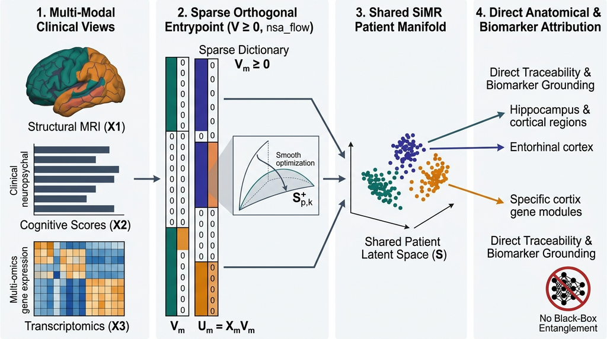

## 2. Effect of Approximate Stiefel Weight w ∈ [0.01, 0.95]

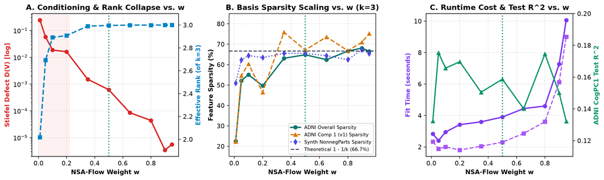